# Room Types and Modifiers

In this lesson, we’ll introduce the notion of *Room* types. We can assign units to “typed” *Rooms* to modify the behavior of our ship.

For example, if we place a unit in the helm *Room*, the ship will have a chance to dodge incoming projectiles.

If a *Unit* gets stationed in the weapons *Room*, then the weapons charge time decreases. And so on.

Room modifiers are tricky because they affect multiple game systems in specialized ways, so we can’t use a generalized recipe.

All I can do here is cover a range of possibilities to give you an idea of tackling this task in specific cases.

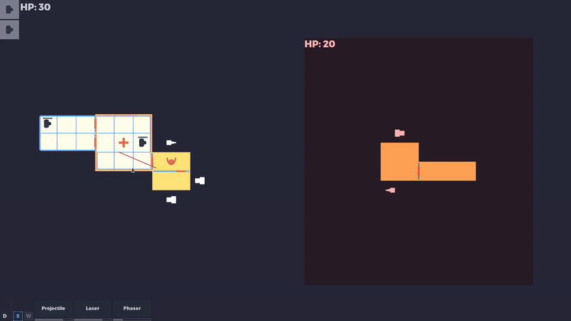

We’ll have the following *Room* types:

- `EMPTY`: which is the default and what we have been using so far.
- `SENSORS`: this *Room* doesn’t need units to function. It lets the player see inside *Rooms* without units including the AI ship.
- `HELM`: when manned, the ship has a chance to evade incoming projectiles.
- `WEAPONS`: when manned, the weapons charge speed increases.
- `MEDBAY`: when units move inside the `MEDBAY` *Room*, they regain hitpoints.

## Rooms with types

We first have to update our *Room* scene to add a visual representation for its type, if it’s something other than `EMPTY`.

[figure not shown]

`Sprite` node before *SpriteTarget*. Rename it to *SpriteType*, as shown in the following picture:

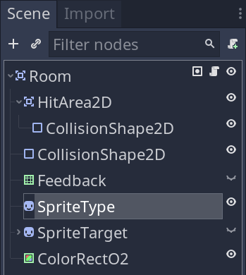

The visuals for the types are white by design, so we can use *Modulate* to colorize them:

[figure not shown]

Let’s set the *SpriteType* properties. Assign `Assets.svg` to `Texture` and turn on *Region -> Enabled*. We don’t have to assign any values to *Region -> Rect* because we’ll do it from code.

Lastly, turn off *SpriteType*’s visibility and change *Modulate* to something that suits your taste. I chose the `#e36956` color.

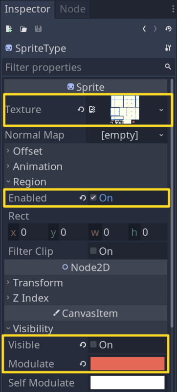

We have finished setting up the *Room* scene and can move on to coding.

## Connecting types to modifiers

Open the `Room.gd` script. We have to update our code to assign types to rooms and update them visually with the images from `Assets.svg`.

We also add a few new signals to emit modifiers’ status as units move from one *Room* to another.

Let’s start at the top with the new signals:

```
# ...
# signal targeted(msg)

## We emit this signal when units move in and out of rooms.
signal modifier_changed(type, value)

## We have to hide the hazards when there's "fog" in a `Room`, i.e., when the
## ship doesn't have sensors, and there's no `Unit` in the `Room`. This signal
## is for that case.
signal fog_changed(room, has_fog)
```

The next block of code is declaring the *Type* enumeration along with some valuable constants and the `type` export variable:

```
## We use the enumeration in the declaration of the export variable, which gives
## us a nice dropdown list in the `Inspector`. See the image below this code
## listing.
enum Type { EMPTY, SENSORS, HELM, WEAPONS, MEDBAY }

## We use a rectangle to hide the Room if units aren't inside it and the ship
## doesn't have sensors. This is its color.
const FOG_COLOR := Color("ffe478")

## These vectors correspond to the `Asset.svg` location of the visuals for each
## type. We use them to assign the `Region -> Rect` property.
const SPRITE := {
    Type.EMPTY: Vector2.INF,
    Type.SENSORS: Vector2(128, 384),
    Type.HELM: Vector2(160, 384),
    Type.WEAPONS: Vector2(128, 416),
    Type.MEDBAY: Vector2(160, 416)
}

export (Type) var type := Type.EMPTY
# export var size := Vector2.ONE setget set_size
# ...
```

The `type` enum show up in the *Inspector* like this:

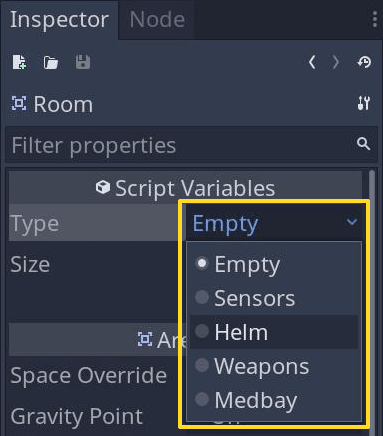

We still have to define a few new variables.

Instead of treating modifiers differently depending on their connection to the *Room* type, I’m using the same “interface”. This means that some modifiers don’t do anything, even though we emit them.

Let’s look at the actual declaration to understand this concept:

```
# ...
# var _target_index := -1
var _modifiers := {
    Type.EMPTY: [0.0, 0.0],
    Type.SENSORS: [0.0, 0.0],
    Type.HELM: [0.0, 0.5],
    Type.WEAPONS: [1.0, 2.0],
    Type.MEDBAY: [0.0, 0.0]
}
```

I have modifiers emit every time a *Unit* moves **in and out** of a Room.

If we take `Type.HELM` as an example, the first value in the array, **`[`0.0`, ...]`**, is the value of the modifier when the *Room* ** isn’t manned**. The second value,** `[..., 0.5]`**, is the modifier’s value when the Room** is manned**.

You see that some are `[0.0, 0.0]`, which means they do not affect the game systems through modifiers. They do have effects, but they’re implemented differently. With this setup, the “default” value doesn’t have to be `0.0`. We’ll see concrete examples shortly.

Let’s declare the `_fog` variable next:

```
## We use the `_fog` variable with `_draw()` to hide the `Room` with a rectangle
## instead of using nodes. The dictionary keys are the conditions to either
## reveal the `Room` (`false`) or to hide it (`true`). We assign the `true` key
## in the `setup()` function.
var _fog := {false: Rect2()}
# var _rng := RandomNumberGenerator.new()
# ...
```

We could have used nodes here, but it would have complicated the situation slightly because draw order matters, `e.g`., hazards vs. room types.

It was easier for me to “fix” this issue from code.

Finally, we declare the reference to the new `SpriteType` node:

```
# ...
# onready var color_rect_o2: ColorRect = $ColorRectO2
onready var sprite_type: Sprite = $SpriteType
```

We update the `setup()` function to account for the new node and to update `_fog`:

```
func setup(tilemap: TileMap) -> void:
    # ...
    # color_rect_o2.rect_size = feedback.rect_size

    sprite_type.visible = type != Type.EMPTY
    sprite_type.region_rect = Rect2(SPRITE[type], _tilemap.cell_size / 2)

    # The reason we couldn't previously declare the `true` key is that it
    # depends on the calculated values.
    _fog[true] = Rect2(feedback.rect_position, feedback.rect_size)
```

We can move on to the `_ready()` function and add a special setup for the `MEDBAY` *Room*:

```
func _ready() -> void:
    if Engine.editor_hint:
        return

    # ...
    # _rng.randomize()

    # We dynamically construct a `Timer` node for each `MEDBAY` `Room`.
    if type == Type.MEDBAY:
        var medbay_timer := Timer.new()
        medbay_timer.connect("timeout", self, "_on_MedbayTimer_timeout")
        medbay_timer.autostart = true
        add_child(medbay_timer)
```

Let’s update the `_on_area_entered_exited()` function to account for the units moving in and out of a *Room*:

```
func _on_area_entered_exited(area: Area2D, has_entered: bool) -> void:
    # ...
    # elif area.is_in_group("unit"):
    # if has_entered:
    # units[area.owner] = null
            emit_signal("modifier_changed", type, _modifiers[type][1])
    # else:
    # units.erase(area.owner)
            # If the Room is empty, only then, emit the "default" modifier
            # value.
            if units.empty():
                emit_signal("modifier_changed", type, _modifiers[type][0])

        # This call is to tell Godot to execute `_draw()` for updating the "fog"
        # state if necessary.
        update()
```

The last two remaining functions are `_on_MedbayTimer_timeout()` and `_draw()`:

```
func _on_MedbayTimer_timeout() -> void:
    # Heal all units currently in the `MEDBAY` `Room`. We'll see how this works
    # in the `Unit.gd` script.
    for unit in units:
        unit.heal()


func _draw() -> void:
    if Engine.editor_hint:
        return

    # I found it easier to reason from a "fog" point of view. `ShipAI` will
    # always have `has_sensors` set to the same value as
    # `ShipPlayer.has_sensors` because we want to show the action from the
    # player point of view.
    var has_fog: bool = not owner.has_sensors
    if owner.is_in_group("player"):
        has_fog = has_fog and units.empty()

        # Remember that this gets updated when units move in and out of rooms.
        # We also emit the `fog_changed` signal with every `_draw()` call.
        emit_signal("fog_changed", self, has_fog)
    draw_rect(_fog[has_fog], FOG_COLOR)
```

With these two functions, we have completed updating the `Room.gd` script.

Next, let’s get the small script changes out of the way. This means adding the heal ability to `Unit.gd` and making `Weapon.gd` take the `WEAPONS` *Room* modifier into account.

## Healing units

I chose to use an export variable in the *Unit* class for the healing ability, like in the previous lesson, where I opted to store the oxygen damage power in the *Unit* class.

This allows us to assign different healing rates to each *Unit* if we choose to do so. This may be a contested design choice, it’s up to you to figure out if you want it to be a property of the `MEDBAY` *Room* or, like here, a property of each *Unit*.

Open the `Unit.gd` script, and let’s add the `heal_recovery` variable at the top:

```
# ...
# export var o2_damage := 10
export var heal_recovery := 15
```

The `heal()` function is as simple as it can be:

```
func heal() -> void:
    hitpoints.value += heal_recovery
```

The reason why we’d want a `heal()` function, even in this simple case, is for readability.

Compare `unit.heal()` with `unit.hitpoints.value += unit.heal_recovery`. I think it’s clear which one’s the winner here.

## Boosting weapon’s charging

We introduced a `WEAPONS` *Room* type, and we want the weapons to recharge faster when units are stationed in it.

Open the `Weapon.gd` script to update the code:

```
# ...
# var is_charging := false setget set_is_charging
var modifier := 1.0 setget set_modifier
```

We add a new variable at the top that will influence how fast the weapons will charge. Its base value is `1.0`, as you might have guessed. We’ll multiply this value with the `Tween.speed` property:

```
func set_modifier(value: float) -> void:
    modifier = value
    tween.speed = modifier
```

It’s as simple as the update to the *Unit* class. We handle the logic to connect the modifiers with the *Room* types in the *ShipTemplate* class.

## Handling modifier updates

We handle the *Room* signal emissions in the `ShipTemplate.gd` script.

This is where we have to code in a specialized way, depending on the modifier. There’s no generic way to handle them.

Let’s begin. Open the `ShipTemplate.gd` script, and let’s start at the top with a few new variables:

```
var has_sensors := false

var _evasion := 0.0
# var _slots := {}
# ...
```

We add the `connect()` calls for the new *Room* signals in the `_ready_not_editor_hint()`function :

```
func _ready_not_editor_hint() -> void:
    # ...
    # for room in rooms.get_children():
        room.connect("modifier_changed", self, "_on_Room_modifier_changed")
        room.connect("fog_changed", self, "_on_Room_fog_changed")
```

And at the end of the same for loop, we need to handle the particular case of the `SENSORS` *Room*:

```
func _ready_not_editor_hint() -> void:
    # ...
    # for room in rooms.get_children():
        # tilemap.set_cellv(point, 0)

    # If there's one or more rooms of type `SENSORS`, `has_sensors` will be
    # set to `true` only for the player ship. `ShipAI.has_sensors` is
    # handled in the `TacticalSpaceCombat` class because it's based on the
    # `ShipPlayer` value.
    if is_in_group("player") and room.type == Room.Type.SENSORS:
        has_sensors = true
```

For handling projectile evasion when units are stationed in the `HELM` *Room*, we need to update the `_on_RoomHitArea2D_body_entered()` function:

```
 func _on_RoomHitArea2D_body_entered(body: RigidBody2D, room: Room) -> void:
-   if not room.position.is_equal_approx(body.params.target_position):
+ if not room.position.is_equal_approx(body.params.target_position) or _rng.randf() < _evasion:
      return
```

Let’s now add the two callback functions for the new *Room* signals:

```
func _on_Room_modifier_changed(type: int, value: float) -> void:
    match type:
        Room.Type.HELM:
            _evasion = value
        Room.Type.WEAPONS:
            for controller in weapons.get_children():
                controller.weapon.modifier = value


func _on_Room_fog_changed(room: Room, has_fog: bool) -> void:
    for hazard in hazards.get_children():
        if room.has_point(tilemap.world_to_map(hazard.position)):
            hazard.visible = not has_fog
```

In `_on_Room_modifier_changed()`, we update the appropriate values based on the *Room* type.

As for `_on_Room_fog_changed()`, we need to update the visibility of the hazards depending on the “fog” state of the *Room*.

We’ll have to handle a few exceptional cases considering the “fog” state. These are:

1. When fire spreads.
2. When we first spawn the hazards in `_handle_attack()`.

We first introduce a utility function to check the “fog” state of the *Room*:

```
func _has_fog(room: Room) -> bool:
    var room_has_fog := not has_sensors
    if is_in_group("player"):
        room_has_fog = room_has_fog and room.units.empty()
    return room_has_fog
```

If you remember, this is the same code we used in the *Room* class in `_draw()`. Here’s the excerpt:

```
var has_fog: bool = not owner.has_sensors
if owner.is_in_group("player"):
    has_fog = has_fog and units.empty()
```

We extract it into a function here instead of repeating it in the places we need to update. Let’s start with `_on_Fire_spread()`:

```
func _on_Fire_spread(fire_position: Vector2) -> void:
    # ...
    # fire.connect("spread", self, "_on_Fire_spread")
    for room in rooms.get_children():
        if room.has_point(tilemap.world_to_map(fire.position)):
            var room_has_fog: bool = not has_sensors and room.units.empty()
            fire.visible = not _has_fog(room)
            break
```

And lastly, for the `_handle_attack()` function:

```
func _handle_attack(params: Dictionary, room: Room) -> void:
    var room_has_fog := _has_fog(room)

    # ...
    # fire.connect("attacked", self, "_take_damage")
    # fire.connect("spread", self, "_on_Fire_spread")
    fire.visible = not room_has_fog

    # For `Breach`, we need to use the return value of `hazards.add()`.
    # if _rng.randf() < params.chance_breach:
        var breach: Breach = hazards.add(BreachScene, room.randvi())
        if breach != null:
            breach.visible = not room_has_fog
```

Now we have handled the exceptional cases of the *Room* modifiers, we have one last place to update, the *TacticalSpaceCombat* class.

## Ship sensors in the main script

We need to add a button to the bottom systems UI to visually show that the player ship has at least one `SENSORS` *Room*.

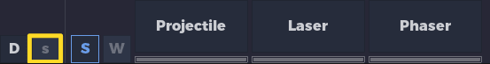

Open `TacticalSpaceCombat.gd` and start by adding the `_ready_sensors()` function call in the `_ready()` function. We’ll write it after.

```
func _ready() -> void:
    # ...
    # ui_doors.connect("pressed", ship_player, "_on_UIDoorsButton_pressed")

    _ready_sensors()
    # _ready_shield()
    # ...
```

Remember that we add the UI buttons in the order of the function calls, so we place `_ready_sensors()` before `_ready_shield()`.

And now for the function:

```
func _ready_sensors() -> void:
    # `ShipAI` uses the same value as `ShipPlayer`. When checking for "fog", the
    # difference is that, with `ShipPlayer`, we also check for unit presence in
    # the rooms.
    ship_ai.has_sensors = ship_player.has_sensors

    # Hide units if `ShipPlayer` doesn't have sensors.
    for unit in ship_ai.units.get_children():
        unit.visible = ship_player.has_sensors

    # Add the (disabled) sensors button at the bottom of the UI if `ShipPlayer`
    # has senssors.
    if ship_player.has_sensors:
        var ui_sensors := UISystem.instance()
        ui_sensors.text = "s"
        ui_sensors.disabled = true
        ui_systems.add_child(ui_sensors)
    ui_systems.add_child(VSeparator.new())
```

And with this function, we finished implementing the modifier mechanisms based on *Room* types.

## Checking our progress

To check our work so far, you can change a few rooms via the Type property in the Inspector in the ShipPlayer scene.

Due to `Room.gd` being a `tool` script, you’ll get the sprites to show up for specialized rooms if you save your ship scene and reload it with *Scene -> Reload Saved Scene*:

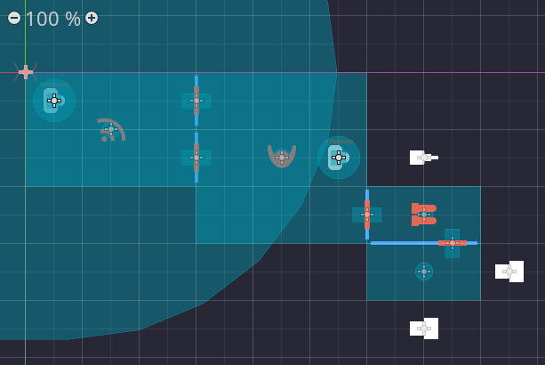

Note that this is more of an unintended artifact. The sprites don’t update in real-time, but only when opening or reloading the scene.

If you now play the demo, you should use the units to affect how different systems operate, such as decreasing the weapons charge time.

## Conclusion

In this lesson, we saw how to add specializations to our rooms.

We added a visual representation to each *Room* that isn’t empty, and we did most of the work from code to be flexible.

We added “modifiers” to the rooms that use a common interface to trigger changes as rooms become manned or unmanned.

These cases are different enough to showcase how to reason with specialized solutions as we can’t generically handle them all.

We’ll finish the course in the next lesson by adding a few minor VFX improvements to make our work pop.

## Code reference

`res://TacticalSpaceCombat/Ship/Rooms/Room.gd`:

```
tool
class_name Room
extends Area2D

signal targeted(msg)
signal modifier_changed(type, value)
signal fog_changed(room, has_fog)

enum Type { EMPTY, SENSORS, HELM, WEAPONS, MEDBAY }

const FOG_COLOR := Color("ffe478")
const SPRITE := {
    Type.EMPTY: Vector2.INF,
    Type.SENSORS: Vector2(128, 384),
    Type.HELM: Vector2(160, 384),
    Type.WEAPONS: Vector2(128, 416),
    Type.MEDBAY: Vector2(160, 416)
}

export (Type) var type := Type.EMPTY
export var size := Vector2.ONE setget set_size

var units := {}
var o2 := 100 setget set_o2

var _target_index := -1
var _modifiers := {
    Type.EMPTY: [0.0, 0.0],
    Type.SENSORS: [0.0, 0.0],
    Type.HELM: [0.0, 0.5],
    Type.WEAPONS: [1.0, 2.0],
    Type.MEDBAY: [0.0, 0.0]
}

var _fog := {false: Rect2()}
var _rng := RandomNumberGenerator.new()
var _entrances := {}
var _area := 0
var _top_left := Vector2.ZERO
var _bottom_right := Vector2.ZERO

var _iter_index := 0

var _tilemap: TileMap = null

onready var collision_shape: CollisionShape2D = $CollisionShape2D
onready var feedback: NinePatchRect = $Feedback
onready var sprite_target: Sprite = $SpriteTarget
onready var hit_area: Area2D = $HitArea2D
onready var color_rect_o2: ColorRect = $ColorRectO2
onready var sprite_type: Sprite = $SpriteType


func setup(tilemap: TileMap) -> void:
    _tilemap = tilemap
    _setup_extents()

    if not Engine.editor_hint:
        hit_area.collision_mask = (
            Global.Layers.SHIPPLAYER
            if owner.is_in_group("player")
            else Global.Layers.SHIPAI
        )

    _area = size.x * size.y
    _top_left = _tilemap.world_to_map(position - collision_shape.shape.extents)
    _bottom_right = _top_left + size

    feedback.rect_position -= collision_shape.shape.extents
    feedback.rect_size = 2 * collision_shape.shape.extents

    color_rect_o2.rect_position = feedback.rect_position
    color_rect_o2.rect_size = feedback.rect_size

    sprite_type.visible = type != Type.EMPTY
    sprite_type.region_rect = Rect2(SPRITE[type], _tilemap.cell_size / 2)

    _fog[true] = Rect2(feedback.rect_position, feedback.rect_size)


func _setup_extents() -> void:
    if _tilemap != null:
        collision_shape.shape.extents = 0.5 * _tilemap.map_to_world(size)


func _ready() -> void:
    if Engine.editor_hint:
        return

    connect("mouse_entered", self, "_on_mouse_entered_exited", [true])
    connect("mouse_exited", self, "_on_mouse_entered_exited", [false])
    connect("area_entered", self, "_on_area_entered_exited", [true])
    connect("area_exited", self, "_on_area_entered_exited", [false])
    connect("input_event", self, "_on_input_event")
    _rng.randomize()

    if type == Type.MEDBAY:
        var medbay_timer := Timer.new()
        medbay_timer.connect("timeout", self, "_on_MedbayTimer_timeout")
        medbay_timer.autostart = true
        add_child(medbay_timer)


func _on_input_event(_v: Viewport, event: InputEvent, _s: int) -> void:
    if (
        event.is_action_pressed("left_click")
        and Input.get_current_cursor_shape() == Input.CURSOR_CROSS
        and _target_index != -1
    ):
        sprite_target.visible = true
        sprite_target.get_child(_target_index).visible = true
        emit_signal(
            "targeted",
            {
                "type": Controller.Type.PROJECTILE,
                "index": _target_index,
                "target_position": position
            }
        )
        _target_index = -1


func _on_mouse_entered_exited(has_entered: bool) -> void:
    feedback.visible = has_entered
    var group := "selected-room"
    if has_entered:
        add_to_group(group)
    elif is_in_group(group):
        remove_from_group(group)


func _on_area_entered_exited(area: Area2D, has_entered: bool) -> void:
    if area.is_in_group("door"):
        var entrance := position - area.position
        entrance = entrance.project(Vector2.DOWN.rotated(area.rotation)).normalized()
        entrance *= 0.5 * _tilemap.cell_size.x
        entrance += area.position
        entrance = _tilemap.world_to_map(entrance)
        _entrances[entrance] = null

    elif area.is_in_group("unit"):
        if has_entered:
            units[area.owner] = null
            emit_signal("modifier_changed", type, _modifiers[type][1])
        else:
            units.erase(area.owner)
            if units.empty():
                emit_signal("modifier_changed", type, _modifiers[type][0])
        update()


func _on_Controller_targeting(msg: Dictionary) -> void:
    _target_index = msg.index
    if _target_index != -1:
        sprite_target.visible = false
        sprite_target.get_child(_target_index).visible = false
        for node in sprite_target.get_children():
            if node.visible:
                sprite_target.visible = true
                break


func _on_MedbayTimer_timeout() -> void:
    for unit in units:
        unit.heal()


func _draw() -> void:
    if Engine.editor_hint:
        return

    var has_fog: bool = not owner.has_sensors
    if owner.is_in_group("player"):
        has_fog = has_fog and units.empty()
        emit_signal("fog_changed", self, has_fog)
    draw_rect(_fog[has_fog], FOG_COLOR)


func randv() -> Vector2:
    var top_left_world := _tilemap.map_to_world(_top_left)
    var bottom_right_world := _tilemap.map_to_world(_bottom_right)
    return Utils.randvf_range(_rng, top_left_world, bottom_right_world)


func randvi() -> Vector2:
    var offset := Utils.randvi_range(_rng, _top_left, _bottom_right - Vector2.ONE)
    offset = _tilemap.map_to_world(offset) + _tilemap.cell_size / 2
    return offset


func has_point(point: Vector2) -> bool:
    return Rect2(_top_left, size).has_point(point)


func set_size(value: Vector2) -> void:
    for axis in [Vector2.AXIS_X, Vector2.AXIS_Y]:
        size[axis] = max(1, value[axis])
    _setup_extents()


func set_o2(value: int) -> void:
    o2 = clamp(value, 0, 100)
    color_rect_o2.color.a = lerp(0.5, 0, o2 / 100.0)


func get_slot(slots: Dictionary, unit: Unit) -> Vector2:
    var out := Vector2.INF
    var entrance := _get_entrance(_tilemap.world_to_map(unit.path_follow.position))

    var valid_positions := []
    for offset in self:
        valid_positions.push_back([offset, offset.distance_to(entrance)])
    valid_positions.sort_custom(self, "sort_by_second_index")

    for data in valid_positions:
        var offset: Vector2 = data[0]
        if not (offset in slots and slots[offset] != unit):
            out = offset
            break
    return out


static func sort_by_second_index(a: Array, b: Array) -> bool:
    return a[1] < b[1]


func _get_entrance(from: Vector2) -> Vector2:
    var out := Vector2.INF
    var distance := INF
    for entrance in _entrances:
        var curve: Curve2D = _tilemap.find_path(from, entrance)
        var length := curve.get_baked_length()
        if distance > length:
            distance = length
            out = entrance
    return out


func _iter_init(_arg) -> bool:
    _iter_index = 0
    return _iter_is_running()


func _iter_next(_arg) -> bool:
    _iter_index += 1
    return _iter_is_running()


func _iter_get(_arg) -> Vector2:
    var offset := Utils.index_to_xy(size.x, _iter_index)
    return _top_left + offset


func _iter_is_running() -> bool:
    return _iter_index < _area
```

`res://TacticalSpaceCombat/Ship/Units/Unit.gd`:

```
class_name Unit
extends Path2D

signal died(unit)

const COLORS := {"default": Color("323e4f"), "selected": Color("3ca370")}

export var speed := 150
export var attack := 15
export var o2_damage := 10
export var heal_recovery := 15

var is_walking: bool setget set_is_walking

onready var path_follow: PathFollow2D = $PathFollow2D
onready var area_unit: Area2D = $PathFollow2D/AreaUnit
onready var hitpoints: ProgressBar = $Hitpoints/Hitpoints


func _ready() -> void:
    area_unit.connect("area_entered", self, "_on_AreaUnit_area_entered")
    area_unit.modulate = COLORS.default
    self.is_walking = false


func _on_AreaUnit_area_entered(area: Area2D) -> void:
    if area.is_in_group("door") and not area.is_open:
        self.is_walking = false


func _process(delta: float) -> void:
    path_follow.offset += speed * delta
    if path_follow.offset >= curve.get_baked_length():
        self.is_walking = false


func walk(path: Curve2D) -> void:
    if path.get_point_count() == 0:
        return

    curve = path
    curve.add_point(path_follow.position, Vector2.ZERO, Vector2.ZERO, 0)
    path_follow.offset = 0
    self.is_walking = true


func heal() -> void:
    hitpoints.value += heal_recovery


func take_damage(other_attack: int) -> void:
    hitpoints.value -= other_attack
    if hitpoints.value <= 0:
        queue_free()
        emit_signal("died", self)


func set_is_walking(value: bool) -> void:
    is_walking = value
    set_process(is_walking)
```

`res://TacticalSpaceCombat/Ship/Weapons/Weapon.gd`:

```
class_name Weapon
extends Sprite

const MIN_CHARGE := 0
const MAX_CHARGE := 100

export var weapon_name := ""
export var charge_time := 2.0
export (int, 0, 5) var attack := 2
export (float, 0, 1) var chance_fire := 0.0
export (float, 0, 1) var chance_breach := 0.0

var is_charging := false setget set_is_charging
var modifier := 1.0 setget set_modifier

var _charge := MIN_CHARGE

onready var tween: Tween = $Tween


func _ready() -> void:
    tween.connect("tween_all_completed", self, "set_is_charging", [false])
    self.is_charging = true


func fire() -> void:
    pass


func set_is_charging(value: bool) -> void:
    is_charging = value
    if is_charging:
        tween.interpolate_property(self, "_charge", MIN_CHARGE, MAX_CHARGE, charge_time)
        tween.start()
    fire()


func set_modifier(value: float) -> void:
    modifier = value
    tween.speed = modifier
```

`res://TacticalSpaceCombat/Ship/ShipTemplate.gd`:

```
tool
extends Node2D

signal hitpoints_changed(hitpoints, is_player)

const LaserTracker := preload("Weapons/LaserTracker.tscn")
const AttackLabel := preload("Weapons/AttackLabel.tscn")
const BreachScene := preload("Hazards/Breach.tscn")
const FireScene := preload("Hazards/Fire.tscn")

export (int, 0, 30) var hitpoints := 30
export (int, 0, 100) var o2_asphyxiation := 10
export (int, 0, 10) var o2_replenish := 2

var has_sensors := false

var _evasion := 0.0
var _slots := {}
var _rng := RandomNumberGenerator.new()

onready var tilemap: TileMap = $TileMap
onready var rooms: Node2D = $Rooms
onready var doors: Node2D = $Doors
onready var units: Node2D = $Units
onready var weapons: Node2D = $Weapons
onready var projectiles: Node2D = $Projectiles
onready var lasers: Node2D = $Lasers
onready var shield: Area2D = $Shield
onready var hazards: Node2D = $Hazards
onready var timer_hazards: Timer = $TimerHazards


func _ready() -> void:
    call("_ready_editor_hint" if Engine.editor_hint else "_ready_not_editor_hint")


func _ready_editor_hint() -> void:
    for room in rooms.get_children():
        room.setup(tilemap)


func _ready_not_editor_hint() -> void:
    timer_hazards.connect("timeout", self, "_on_TimerHazards_timeout")
    _rng.randomize()

    for unit in units.get_children():
        unit.connect("died", self, "_on_Unit_died")
        for door in doors.get_children():
            door.connect("opened", unit, "set_is_walking", [true])

        var position_map := tilemap.world_to_map(unit.path_follow.position)
        _slots[position_map] = unit

    for room in rooms.get_children():
        room.connect("modifier_changed", self, "_on_Room_modifier_changed")
        room.connect("fog_changed", self, "_on_Room_fog_changed")
        room.connect("area_entered", self, "_on_RoomArea2D_area_entered", [room])
        room.hit_area.connect("body_entered", self, "_on_RoomHitArea2D_body_entered", [room])
        room.setup(tilemap)

        for point in room:
            tilemap.set_cellv(point, 0)

        if is_in_group("player") and room.type == Room.Type.SENSORS:
            has_sensors = true

    tilemap.setup(rooms, doors)
    projectiles.setup(rooms.mean_position)
    shield.setup(
        rooms.mean_position,
        Global.Layers.SHIPPLAYER if is_in_group("player") else Global.Layers.SHIPAI
    )


func _get_configuration_warning() -> String:
    var is_verified := (
        is_in_group("player")
        and weapons.get_child_count() <= 4
        or not is_in_group("player")
    )
    return "" if is_verified else "%s can't have more than 4 weapons!" % name


func _unhandled_input(event: InputEvent) -> void:
    if not event.is_action_pressed("right_click"):
        return

    for unit in get_tree().get_nodes_in_group("selected-unit"):
        var point1: Vector2 = tilemap.world_to_map(unit.path_follow.position)
        for room in get_tree().get_nodes_in_group("selected-room"):
            if not room.owner.is_in_group("player"):
                break

            var point2: Vector2 = room.get_slot(_slots, unit)
            if is_inf(point2.x):
                break

            var path: Curve2D = tilemap.find_path(point1, point2)
            Utils.erase_value(_slots, unit)
            _slots[point2] = unit
            unit.walk(path)


func _on_UIDoorsButton_pressed() -> void:
    var has_opened_doors := false
    for door in doors.get_children():
        if door.is_open:
            has_opened_doors = true
            break

    for door in doors.get_children():
        door.is_open = not has_opened_doors


func _on_RoomHitArea2D_body_entered(body: RigidBody2D, room: Room) -> void:
    if not room.position.is_equal_approx(body.params.target_position) or _rng.randf() < _evasion:
        return

    body.queue_free()
    _handle_attack(body.params, room)


func _on_RoomArea2D_area_entered(area: Area2D, room: Room) -> void:
    if area.is_in_group("laser"):
        _handle_attack(area.params, room)


func _on_Room_modifier_changed(type: int, value: float) -> void:
    match type:
        Room.Type.HELM:
            _evasion = value
        Room.Type.WEAPONS:
            for controller in weapons.get_children():
                controller.weapon.modifier = value


func _on_Room_fog_changed(room: Room, has_fog: bool) -> void:
    for hazard in hazards.get_children():
        if room.has_point(tilemap.world_to_map(hazard.position)):
            hazard.visible = not has_fog


func _on_Unit_died(unit: Unit) -> void:
    Utils.erase_value(_slots, unit)
    for room in rooms.get_children():
        room.units.erase(unit)


func _on_Fire_spread(fire_position: Vector2) -> void:
    var neighbor_position := _get_neighbor_position(fire_position)
    var fire: Fire = hazards.add(FireScene, neighbor_position)
    if fire != null:
        fire.connect("attacked", self, "_take_damage")
        fire.connect("spread", self, "_on_Fire_spread")
        for room in rooms.get_children():
            if room.has_point(tilemap.world_to_map(fire.position)):
                fire.visible = not _has_fog(room)
                break


func _on_TimerHazards_timeout() -> void:
    _hazards_breach()
    _hazards_units()
    _hazards_o2()


func _hazards_breach() -> void:
    for hazard in hazards.get_children():
        if hazard is Fire:
            continue

        for room in rooms.get_children():
            if room.has_point(tilemap.world_to_map(hazard.position)):
                room.o2 -= hazard.attack


func _hazards_units() -> void:
    for room in rooms.get_children():
        var hazard_was_attacked := false
        for hazard in hazards.get_children():
            if room.has_point(tilemap.world_to_map(hazard.position)):
                for unit in room.units:
                    if hazard is Fire:
                        unit.take_damage(hazard.attack)

                    if not hazard_was_attacked:
                        hazard.take_damage(unit.attack)
                        hazard_was_attacked = true

                if hazard is Fire and room.o2 < o2_asphyxiation:
                    hazard.take_damage(hazard.o2_damage)

        for unit in room.units:
            if room.o2 < o2_asphyxiation:
                unit.take_damage(unit.o2_damage)


func _hazards_o2() -> void:
    var o2_associations := {}
    var room_associations := {}
    for door in doors.get_children():
        if not door.is_open:
            continue

        var o2_mean := 0.0
        for room in door.rooms:
            o2_mean += room.o2
            room_associations[room] = room_associations.get(room, 0) + 1
        o2_mean /= door.rooms.size()

        for room in door.rooms:
            o2_associations[room] = o2_associations.get(room, 0) + o2_mean

    for room in rooms.get_children():
        if room in o2_associations:
            o2_associations[room] /= room_associations[room]
            room.o2 = lerp(room.o2, o2_associations[room], 0.5)
        room.o2 += o2_replenish

func add_laser_tracker(color: Color) -> Node:
    var laser_tracker := LaserTracker.instance()
    lasers.add_child(laser_tracker)
    laser_tracker.setup(color, rooms, shield)
    return laser_tracker


func _has_fog(room: Room) -> bool:
    var room_has_fog := not has_sensors
    if is_in_group("player"):
        room_has_fog = room_has_fog and room.units.empty()
    return room_has_fog


func _handle_attack(params: Dictionary, room: Room) -> void:
    var room_has_fog := _has_fog(room)

    if _rng.randf() < params.chance_fire:
        var fire: Fire = hazards.add(FireScene, room.randvi())
        if fire != null:
            fire.connect("attacked", self, "_take_damage")
            fire.connect("spread", self, "_on_Fire_spread")
            fire.visible = not room_has_fog

    if _rng.randf() < params.chance_breach:
        var breach: Breach = hazards.add(BreachScene, room.randvi())
        if breach != null:
            breach.visible = not room_has_fog

    _take_damage(params.attack, room.position)


func _take_damage(attack: int, object_position: Vector2) -> void:
    var attack_label := AttackLabel.instance()
    attack_label.setup(attack, object_position)
    add_child(attack_label)

    hitpoints -= attack
    hitpoints = max(0, hitpoints)
    emit_signal("hitpoints_changed", hitpoints, is_in_group("player"))


func _get_neighbor_position(at: Vector2) -> Vector2:
    var neighbors := []
    var point1 := tilemap.world_to_map(at)
    for offset in Utils.DIRECTIONS:
        var point2: Vector2 = point1 + offset
        if tilemap.get_cellv(point2) != tilemap.INVALID_CELL:
            neighbors.push_back(tilemap.map_to_world(point2) + 0.5 * tilemap.cell_size)
    var index := _rng.randi_range(0, neighbors.size() - 1)
    return neighbors[index]
```

`res://TacticalSpaceCombat.gd`:

```
extends Node2D

const UIUnit = preload("TacticalSpaceCombat/UI/UIUnit.tscn")
const UIWeapons = preload("TacticalSpaceCombat/UI/UIWeapons.tscn")
const UIWeapon = preload("TacticalSpaceCombat/UI/UIWeapon.tscn")
const UISystem = preload("TacticalSpaceCombat/UI/UISystem.tscn")

const END_SCENE = "TacticalSpaceCombat/End.tscn"

onready var ship_player: Node2D = $ShipPlayer
onready var ship_ai: Node2D = $ViewportContainer/Viewport/ShipAI
onready var ui_units: VBoxContainer = $UI/Units
onready var ui_doors: Button = $UI/Systems/Doors
onready var ui_systems: HBoxContainer = $UI/Systems
onready var ui_hitpoints_player: Label = $UI/HitPoints
onready var ui_hitpoints_ai: Label = $ViewportContainer/Viewport/UI/HitPoints


func _ready() -> void:
    ship_player.connect("hitpoints_changed", self, "_on_Ship_hitpoints_changed")
    ship_ai.connect("hitpoints_changed", self, "_on_Ship_hitpoints_changed")
    ui_doors.connect("pressed", ship_player, "_on_UIDoorsButton_pressed")

    _ready_sensors()
    _ready_shield()
    _ready_units()
    _ready_weapons_ai()
    _ready_weapons_player()

    _on_Ship_hitpoints_changed(ship_player.hitpoints, true)
    _on_Ship_hitpoints_changed(ship_ai.hitpoints, false)


func _ready_units() -> void:
    for unit in ship_player.units.get_children():
        var ui_unit: ColorRect = UIUnit.instance()
        ui_units.add_child(ui_unit)
        unit.setup(ui_unit)


func _ready_weapons_ai() -> void:
    for controller in ship_ai.weapons.get_children():
        if controller is ControllerAIProjectile:
            controller.connect("targeting", ship_player.rooms, "_on_Controller_targeting")
            controller.weapon.connect(
                "projectile_exited", ship_player.projectiles, "_on_Weapon_projectile_exited"
            )
            ship_player.rooms.connect("targeted", controller, "_on_Ship_targeted")
        elif controller is ControllerAILaser:
            var laser_tracker: Node = ship_player.add_laser_tracker(controller.weapon.color)
            controller.connect(
                "targeting", laser_tracker, "_on_Controller_targeting", [], CONNECT_DEFERRED
            )
            controller.weapon.connect("fire_started", laser_tracker, "_on_Weapon_fire_started")
            controller.weapon.connect("fire_stopped", laser_tracker, "_on_Weapon_fire_stopped")
            laser_tracker.connect("targeted", controller, "_on_Ship_targeted")


func _ready_weapons_player() -> void:
    for controller in ship_player.weapons.get_children():
        if not ui_systems.has_node("Weapons"):
            ui_systems.add_child(UIWeapons.instance())
        var ui_weapon: VBoxContainer = UIWeapon.instance()
        ui_systems.get_node("Weapons").add_child(ui_weapon)

        if controller is ControllerPlayerProjectile:
            controller.weapon.connect(
                "projectile_exited", ship_ai.projectiles, "_on_Weapon_projectile_exited"
            )
            for room in ship_ai.rooms.get_children():
                controller.connect("targeting", room, "_on_Controller_targeting")
                room.connect("targeted", controller, "_on_Ship_targeted")

        elif controller is ControllerPlayerLaser:
            var laser_tracker: Node = ship_ai.add_laser_tracker(controller.weapon.color)
            controller.connect(
                "targeting", laser_tracker, "_on_Controller_targeting", [], CONNECT_DEFERRED
            )
            controller.weapon.connect("fire_started", laser_tracker, "_on_Weapon_fire_started")
            controller.weapon.connect("fire_stopped", laser_tracker, "_on_Weapon_fire_stopped")
            laser_tracker.connect("targeted", controller, "_on_Ship_targeted")
        controller.setup(ui_weapon)


func _ready_shield() -> void:
    var ui_shield := UISystem.instance()
    ui_shield.connect("toggled", ship_player.shield, "set_powered")
    ui_shield.toggle_mode = true
    ui_shield.pressed = ship_player.shield.powered
    ui_shield.disabled = not ship_player.shield.powered
    ui_shield.text = "S"
    ui_systems.add_child(ui_shield)


func _ready_sensors() -> void:
    ship_ai.has_sensors = ship_player.has_sensors
    for unit in ship_ai.units.get_children():
        unit.visible = ship_player.has_sensors

    if ship_player.has_sensors:
        var ui_sensors := UISystem.instance()
        ui_sensors.text = "s"
        ui_sensors.disabled = true
        ui_systems.add_child(ui_sensors)
    ui_systems.add_child(VSeparator.new())


func _on_Ship_hitpoints_changed(hitpoints: int, is_player: bool) -> void:
    var label := ui_hitpoints_player if is_player else ui_hitpoints_ai
    label.text = "HP: %d" % hitpoints
    if hitpoints == 0:
        Global.winner_is_player = not is_player
        get_tree().change_scene(END_SCENE)
```